# avotrex R Package

Joseph P. Wayman and Thomas J. Matthews

This vignette is heavily based on the papers that accompany the package (Matthews et al. 2024; Sayol et al. 2024). To cite this vignette, please cite the corresponding papers:

Matthews et al. (IN REVIEW) The global loss of avian functional and phylogenetic diversity from anthropogenic extinctions.

Sayol et al. (IN REVIEW) AVOTREX: A global dataset of extinct birds and their traits.

## BACKGROUND

The AVOTREX database represents a comprehensive repository of species-level traits for all known extinct bird species (*n = 610*) from the past 130,000 years to the present day (Sayol et al. 2024). The database provides valuable information on geographical location, species island endemicity, and several species-level traits, including flight ability, body mass and eight standard external morphological measurements. The AVOTREX project also aimed to generate a pipeline to graft extinct species onto supplied phylogenetic trees, providing the means to quantify phylogenetic diversity loss (Matthews et al. 2024). This resulted in the ‘avotrex’ R package and the focus of this vignette. The package (avotrex) allows a user to build trees using the AVOTREX database, build multiple trees in parallel, and plot a variety of tree types to display the resultant phylogenies. It has been set up to work with the BirdTree set of phylogenies (Jetz et al. 2012); however, it can be adapted to work with any taxonomy and phylogenetic backbone.

## METHODOLOGY AND FUNCTIONS

The avotrex R package has been programmed using standard S3 methods and is available on CRAN (version 1.3.0); the development version is available on GitHub (joe-wayman/avotrex). The package includes a sample of the BirdTree phylogenetic trees of extant birds (Jetz et al. 2012) alongside the extinct traits database, to allow users to build phylogenetic trees incorporating the extinct species using the methodology detailed below and within (Sayol et al. 2024; Matthews et al. 2024). Further BirdTree phylogenies can be sourced from: https://birdtree.org/. Users can add species to the database allowing them to be included in the produced trees (see “Adding new species” section, below). Therefore, this package represents a resource that allows users to (i) generate as many trees as needed, (ii) easily incorporate new species, (iii) modify codes and instructions provided for extinct species within the database and (iv) use a different phylogenetic tree as a base if other global bird phylogenies become available.

### Tree building - AvoPhylo()

To build trees, we use the AvoPhylo function, which is the primary function within the package. The function provides an algorithmic pipeline to join species onto a provided phylogeny in a set order based on their known taxonomic affinities. These instructions are provided as codes in the “type” column of the “AvotrexPhylo” database. Each code joins the species to the tree in a set manner based on their known taxonomic affinities to currently extant and other extinct species (Table.1). Input phylogenies (e.g., BirdTree trees) must be of class ‘phylo’. Some species need to be joined before others (e.g., the first representative of an extinct taxonomic order needs to be joined as a sister to an entire taxonomic order already in the tree). This ordering is controlled through the “sp_id”, “phylo_id” and “group” columns in the “AvotrexPhylo” database. Before grafting, the database is ordered by the “sp_id” column, with the “phylo_id” and “group” columns used to filter out particular groups of species (i.e., those with the value ‘xS’ in the “phylo_id” column) to be grafted in different orders. The grafting order of species within these groups is randomized before the start of the grafting. This accounts for the fact that there are numerous groups of species in the database for which using a pre-defined grafting order does not effectively account for the uncertainty related to their placement in the tree (e.g., Pacific rails). The “xS” code and Group ID numbers are also used to graft species in particular clades (e.g., the moa) in a specific order by including decimals in the Group ID number (e.g., a hypothetical three species clade given the “group” values of 99.1, 99.2, 99.3, where the species with “group” = 99.1 will be grafted first, and so on).

For a subset of species (primarily those in older clades), we have constrained the grafting to take place at a specific time point (value in the ‘time_fixed’ column) along a given branch, rather than at a randomly selected point. If, due to the topology of the underlying BirdTree tree, it is not possible to undertake this grafting along a given branch (i.e., the time point for grafting is either older than the parent node or younger than the child node, of a focal branch), we graft the species just below the parent node or just above the child node (using a default branch length of 0.1M years; this can be changed using the ‘mindist’ argument). For example, for the elephant birds, we constrained (as close as possible given the underlying tree) the split from Apterygiformes to occur at 54.16Mya, with the divergence of *Mullerornis* from the other species occurring at (or as near as possible to) 27.58Mya.

As can be deduced by the randomization of groups, the uncertainty inherent within the input trees, and the codes used to graft extinct species (Table.1), each tree produced is different. It is, therefore, useful to run the tree building and grafting a number of times to account for this uncertainty. To accommodate the need to produce large number of trees, the package allows the grafting to be conducted on different trees in parallel on multiple cores (see the ‘n.cores’ argument). Note that the function will run on one core as default and if only one tree is supplied. If more than one tree is used, a progress bar will be displayed so users can track the building, which is particularly useful when creating a large number of trees. If more than one tree is provided as the input (using the argument ‘ctrees’), trees for grafting can either be randomly selected from the input trees (setting the ‘ord’ argument to FALSE), or the input trees can (all) be selected in the same order as they are stored in ‘ctrees’ (‘ord’ = TRUE). In the former case, the ‘Ntree’ argument can be used to select a specific number of trees to be randomly sampled from ‘ctrees’, whereas in the latter case, ‘Ntree’ must equal the length of ‘ctrees’.

Table. 1. Joining codes and definitions of how each joins the species onto the global phylogeny.

[output not shown]

Further information on the pipeline and the grafting procedure can be found in Sayol et al. (2024) and Matthews et al. (2024).

```r
# Load package
library(avotrex)

## An example of tree building
data(BirdTree_trees)
data(BirdTree_tax)
data(AvotrexPhylo)
trees <- AvoPhylo(ctrees = BirdTree_trees,   # BirdTree tree(s)
                  avotrex = AvotrexPhylo,    # The extinct species phylogeny database
                  PER = 0.2,                 # Perecentage/fraction for branch truncation
                  PER_FIXED = 0.75,          # Point along the branch to graft the species
                  tax = BirdTree_tax,        # Taxonomy
                  Ntree = 2,                 # Number of trees
                  n.cores = 2)               # Number of cores
```

## ADDING NEW SPECIES

The avotrex package has been created to allow users to incorporate new extinct species into the database as further extinctions are unearthed or further species go extinct. Here we provide an example of adding a species into the database for the simplest example, i.e., a species addition that makes no changes to the plotting order or grafting code of any other species in the database. For illustrative purposes we use a made up species *Vapor hams*.

```r
library(avotrex)
#Create a new species to add to the main database; not the
#values in the vector match the columns in AvotrexPhylo
vaporhams <- c("x644", "x644", "FALSE", NA, NA, "Vapor_hams",
               "Strigiformes", "Strigidae", "Athene",
               "STRIGIFORMES", "Strigidae", "Athene",
               "S", NA, NA, NA, "Athene", "noctua", NA)

#Just for speed, filter the main database just to include owls.
#However, note that in this case, the 12 'AP' species are not
#removed completely as they are already in BirdTree.
AvotrexPhylo2 <- AvotrexPhylo[AvotrexPhylo$order == 'Strigiformes',]

#Add the new owl species. The species can be added as a final row
#to AvotrexPhylo as adding it makes no changes to other
#taxonomic affinities and therefore, no change to the grafting
#order

AvotrexPhylo3 <- rbind(AvotrexPhylo2, vaporhams)

#Graft species to a Jetz tree
trees <- AvoPhylo(ctrees = BirdTree_trees,
                  avotrex = AvotrexPhylo3,
                  PER = 0.2,
                  tax = BirdTree_tax,
                  Ntree = 1)
```

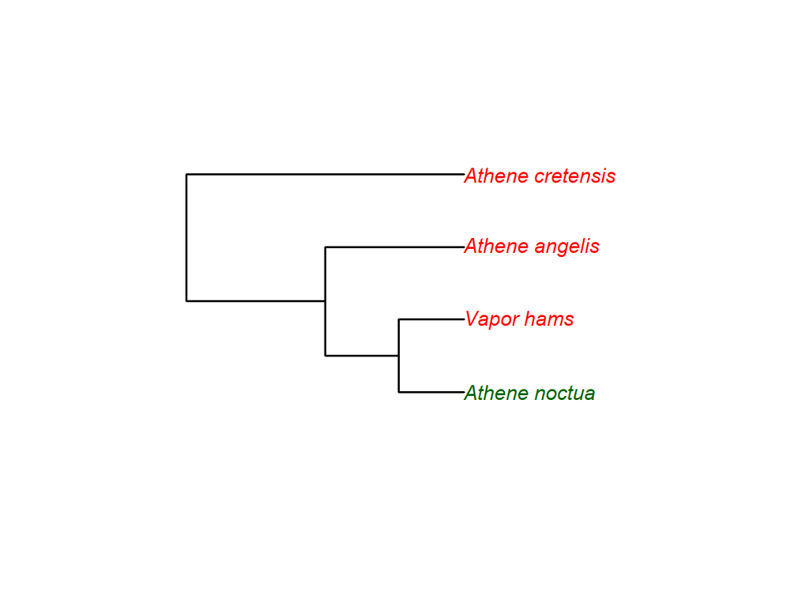

```r
##single species; 3 levels back
plot(trees[[1]],
     avotrex = AvotrexPhylo3,
     tax = BirdTree_tax,
     species = "Vapor_hams",
     tips = "all_dif",
     tips_col = c("red", "darkgreen"),
     lvls = 3,
     type = "phylogram",
     cex = 0.6)
```

Some species may have to be joined in a more complicated way, depending upon their taxonomic affinities with both extant and extinct species. For example, if a newly added species is a closer relative to a species than an extinct species currently in the database that has the code ‘S’ (meaning it is joined as a sister) then both the types of grafting code and the grafting order need to be updated. The package authors can be contacted when assistance is needed adding single or multiple species.

## PLOTTING

The avotrex package, when loaded, provides the user with a number of ways to plot produced trees to visually examine or display the branching patterns. The function uses the ape package’s ‘plot.phylo’ function (Paradis, Claude, and Strimmer 2004) and can take any argument from that function (e.g. the ‘type’ argument). Below we show a number of examples of what is possible using the plot function with a set of example trees provided within the package (treesEx).

Note - if using the ‘lvls’ argument, a warning is provided. This comes from the tidytree::tree_subset function and appears to be a bug (but the plot should be checked for sense).

Plotting all extant and extinct species can be messy due to the number of tips, but it can be useful to assess whole phylogenies. However, the ‘type’ argument plots the phylogeny as a fan, allowing for tidier visualization.

```r
library(avotrex)

data(BirdTree_trees)
data(BirdTree_tax)
data(AvotrexPhylo)
data(treesEx)

# #all species - no tip names
# plot(treesEx[[1]],
#      avotrex = AvotrexPhylo,
#      tax = BirdTree_tax,
#      tips = "none",
#      type = "fan")
```

Users can select a specific order, family, or genus to plot. The tip labels can be changed to show only extinct species labels (“tips == extinct”), all of the species in the same colour (“all_same”), all of the species but with extinct labels in a separate colour (“all_dif”), or no labels (“none”). See the help documentation for ‘plot.avophylo()’ for further information.

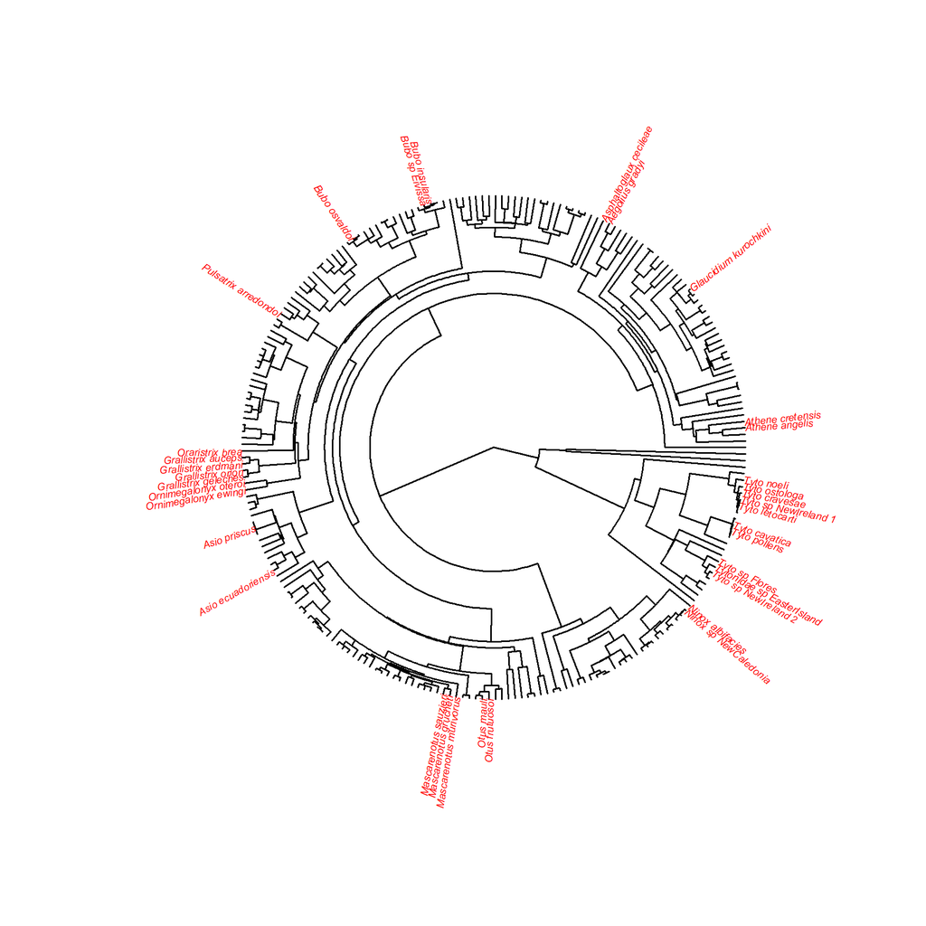

```r
#order (owls) - just show extinct tip names (in red) and using
#a fan plot
plot(treesEx[[1]],
     avotrex = AvotrexPhylo,
     tax = BirdTree_tax,
     order = "Strigiformes",
     tips = "extinct",
     type = "fan",
     tip.color = "red",
     cex = 0.4)
```

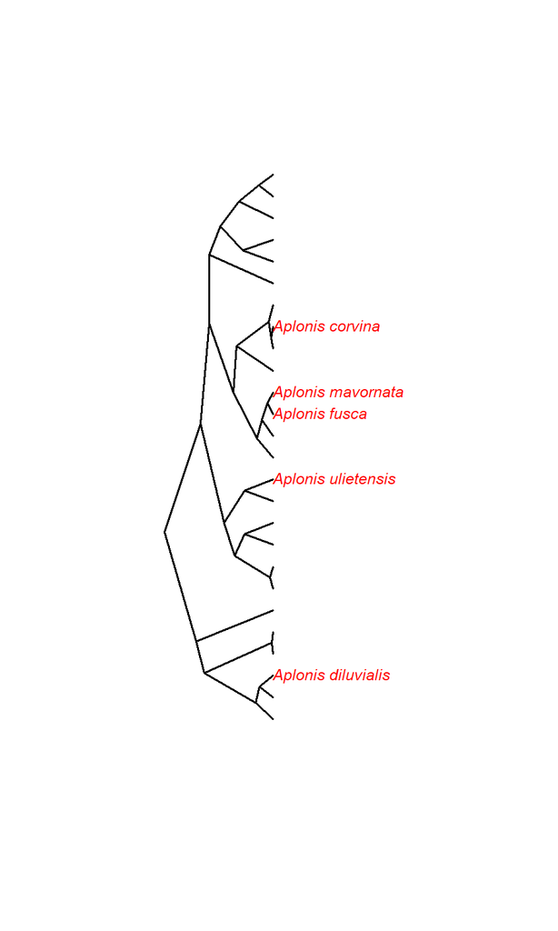

```r
#genus - cladogram plot
plot(treesEx[[2]],
     avotrex = AvotrexPhylo,
     tax = BirdTree_tax,
     genus = "Aplonis",
     tips = "extinct",
     type = "cladogram",
     tip.color = "red",
     cex = 0.5)
```

If multiple trees are supplied to the plot function, then each tree is returned in turn.

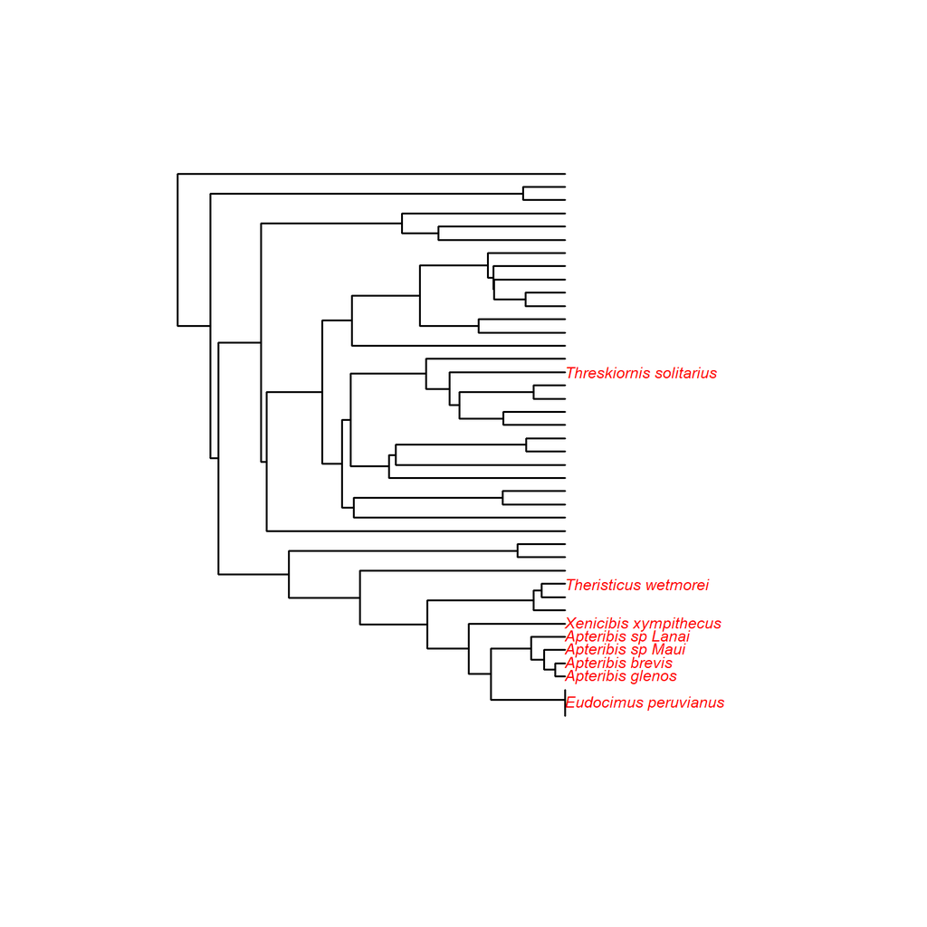

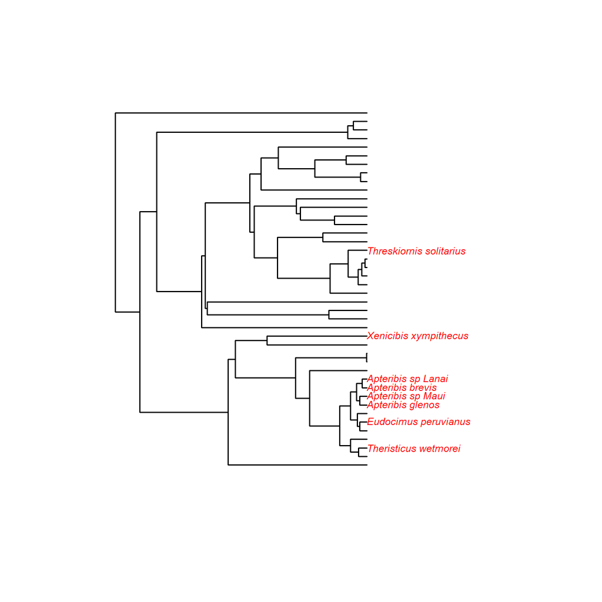

```r
#family (plot all two trees this time)
plot(treesEx,
     avotrex = AvotrexPhylo,
     tax = BirdTree_tax,
     family = "Threskiornithidae",
     tips = "extinct",
     tip.color = "red",
     cex = 0.5)
```

As well as taxonomic groups, the plot function can also take a list of species.

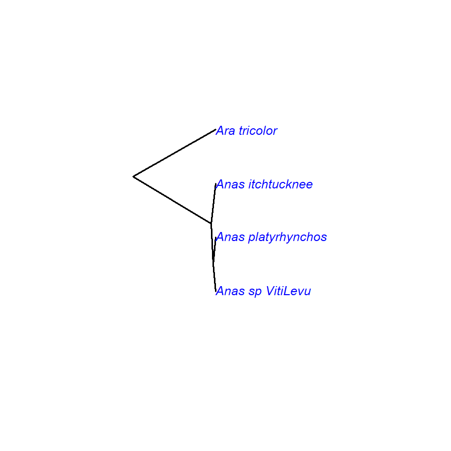

```r
#species (& show all tip names in same colour)
species2 <- c("Anas_itchtucknee", "Anas_sp_VitiLevu",
              "Anas_platyrhynchos", "Ara_tricolor")

plot(treesEx[[2]], avotrex = AvotrexPhylo, tax = BirdTree_tax,
     species = species2, tips = "all_same",
     type = "cladogram",
     tip.color = "blue", cex = 0.5)
```

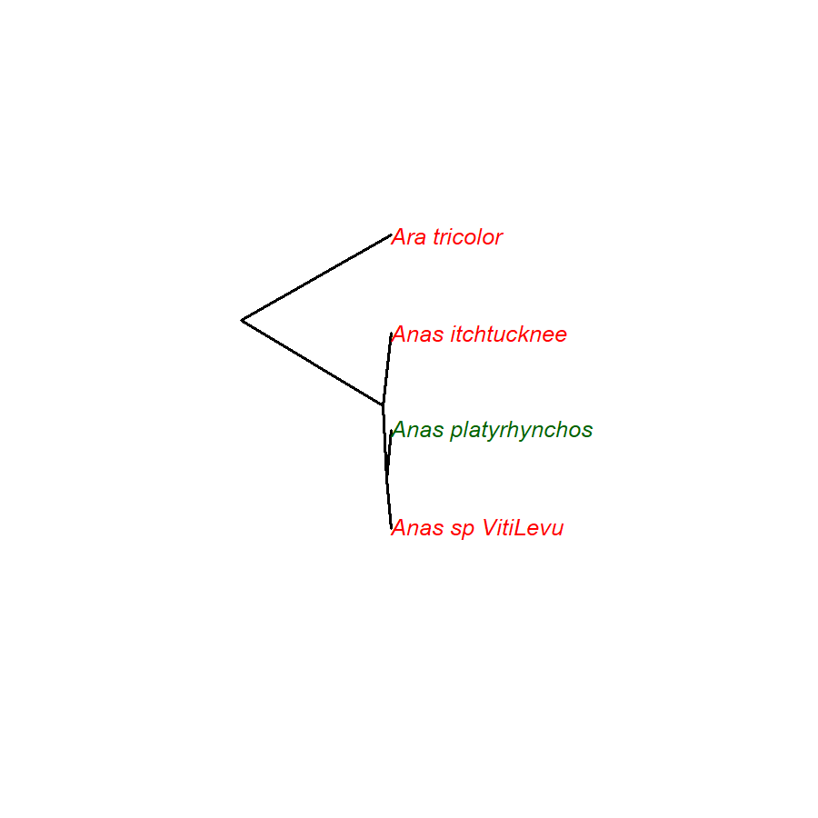

```r
#same as previous, but extinct and extant diff colours
plot(treesEx[[2]], avotrex = AvotrexPhylo, tax = BirdTree_tax,
     species = species2,
     cex = 0.5, tips = "all_dif",
     tips_col = c("red", "darkgreen"),
     type = "cladogram")
```

Lastly, the plot function can take a single species, with the number of levels back (i.e., rootward) it includes determined by the ‘lvls’ argument.

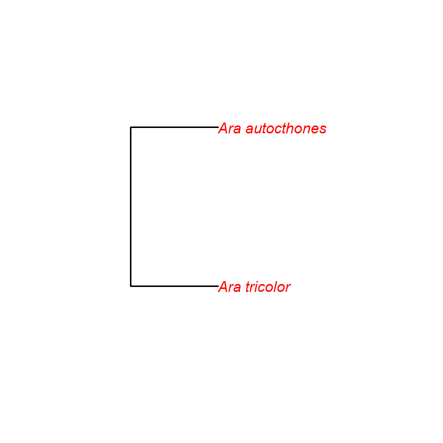

```r
##single species only 1 level back
plot(treesEx[[2]], avotrex = AvotrexPhylo, tax = BirdTree_tax,
     species = "Ara_tricolor",
     tips = "all_dif",
     tips_col = c("red", "darkgreen"),
     lvls = 1,
     type = "phylogram",
    cex = 0.6)
```

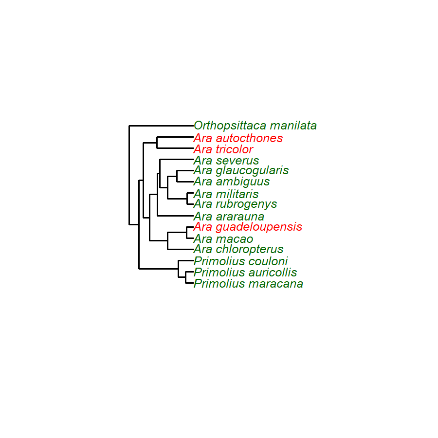

```r
#increase levels back
plot(treesEx[[2]], avotrex = AvotrexPhylo,
     tax = BirdTree_tax,
     species = "Ara_tricolor",
     tips = "all_dif",
     tips_col = c("red", "darkgreen"),
     lvls = 4,
     type = "phylogram",
     cex = 0.5)
```

## REFERENCES

Jetz, W., G. H. Thomas, J. B. Joy, K. Hartmann, and A. O. Mooers. 2012. “The Global Diversity of Birds in Space and Time.” Journal Article. *Nature* 491: 444–48. https://doi.org/10.1038/nature11631.

Matthews, T. J., K. Triantis, J. P Wayman, and et al. 2024. “The Global Loss of Avian Functional and Phylogenetic Diversity from Anthropogenic Extinctions.” Journal Article. *In Review*.

Paradis, E., J. Claude, and K. Strimmer. 2004. “APE: Analyses of Phylogenetics and Evolution in r Language.” Journal Article. *Bioinformatics* 20: 289–90. https://doi.org/10.1093/bioinformatics/btg412.

Sayol, F., J. P. Wayman, P. Dufour, and et al. 2024. “AVOTREX: A Global Dataset of Extinct Birds and Their Traits.” Journal Article. *In Review*.